# Tutorial - Monte Carlo Simulation

# Using simulation to understand properties of random variables

A central topic in statistics is determining the properties of different random variables (e.g. what are their expectations and variances?). Additionally, we often obtain results for the **large-sample** behavior of an estimator, but how good is that approximation in a particular finite sample? Often these properties are difficult or cumbersome to analyze theoretically.

A very common tool that is used to obtain numerical results in lieu of analytical ones is the *monte carlo* simulation. The principle is simple - the law of large numbers.

We can approximate the properties of some random variable $X$ – typically expectations of functions (which includes the mean, the variance, etc…) – by taking a repeated number of *i.i.d.* draws from that random variable and then computing the corresponding sample quantity of interest from the distribution of those draws. For example, if we wanted to know the expectation of some random variable, we can take a large number of independent, repeated draws from that random variable, store those draws, and compute the average. As we let the number of draws get arbitrarily large (our only limitation is computing resources and time), this will converge to the true expected value.

In practice, you see simulations in statistical methods papers all the time, often to illustrate certain properties of an estimator where the intuition may not be clear just from the analytical result or to get some sense of properties that are difficult to derive. For example, in papers where much of the theory relies on asymptotic approximations, we may use simulations to get a sense of how good the approximation is in small samples or to compare the performance of different estimators across fixed sample sizes.

You also will find simulations useful as a way of checking analytical results - it’s easy for a proof to go wrong or to be unsure of some of the steps, so it can help to use a simulation to understand what the correct answer *should* be at least for a particular set of parameter values. Simulations can be a great way of generating intuition when analytical results are hard to come by.

# Common tools of simulation

In conducting a simulation, you will typically rely on two sets of programming tools: random number generator functions and loops.

## Random number generators

R has a suite of functions to allow you to generate (pseudo)-random numbers from particular distributions. These functions typically start with `r` and the name of the distribution. For example, the function to generate random draws from the normal is `rnorm`. Built-in functions cover most of the common ones: uniform, bernoulli, binomial, normal, poisson, etc… and other packages exist for more esoteric distributions. Because computers are deterministic, the algorithms that generate these numbers are not truly “random” in the sense that the exact sequence of random numbers can be reproduced if one knows the initial “seed” for the algorithm. These random number generators create sequences of numbers that have the *properties* of randomness (e.g. independence), but they can be replicated for a fixed seed. This is actually great for us researchers since it ensures replicability. Even if you are using a simulation, I can reproduce your exact numeric results if I fix the seed. However, this does mean that you need to be aware of when you set the seed in your algorithm. Set it once in your script or code fragment and don’t change it.

```r
# Set the seed for a random number generator
set.seed(53706)

# Generate N=100 random normal variates
rand_norm <- rnorm(100, mean=2, sd=1)

# Calculate the mean - it's close to 2
print(mean(rand_norm))
```

```
[1] 2.025358
```

```r
# Note that if I run this fragment again and again, I will get the exact
# same values in rand_norm - this is because the seed is fixed at the top of
# the fragment!
```

In a simulation, you will need to generate draws from a random variable *multiple times*. Often this will be some sort of function of other random variables – remember, all an estimator is is a function of other random variables. There will not be an existing routine that does this for you, so you will need to write your own code that takes as input some random numbers and generates the desired output (e.g. a difference-in-means, a regression estimator, etc…). You probably don’t want to copy and paste this code 1 million times, so you’ll need a way of repeating the same process with different random inputs and storing the results.

```r
set.seed(53706) # Set random seed
niter <- 100000 # Number of for loop iterations
sample_means <- replicate(niter, mean(rbinom(n=50, size=1, prob=.5)))
# What's the mean of the sampling distribution? The population mean E[X_i]
mean(sample_means)
```

```
[1] 0.4999202
```

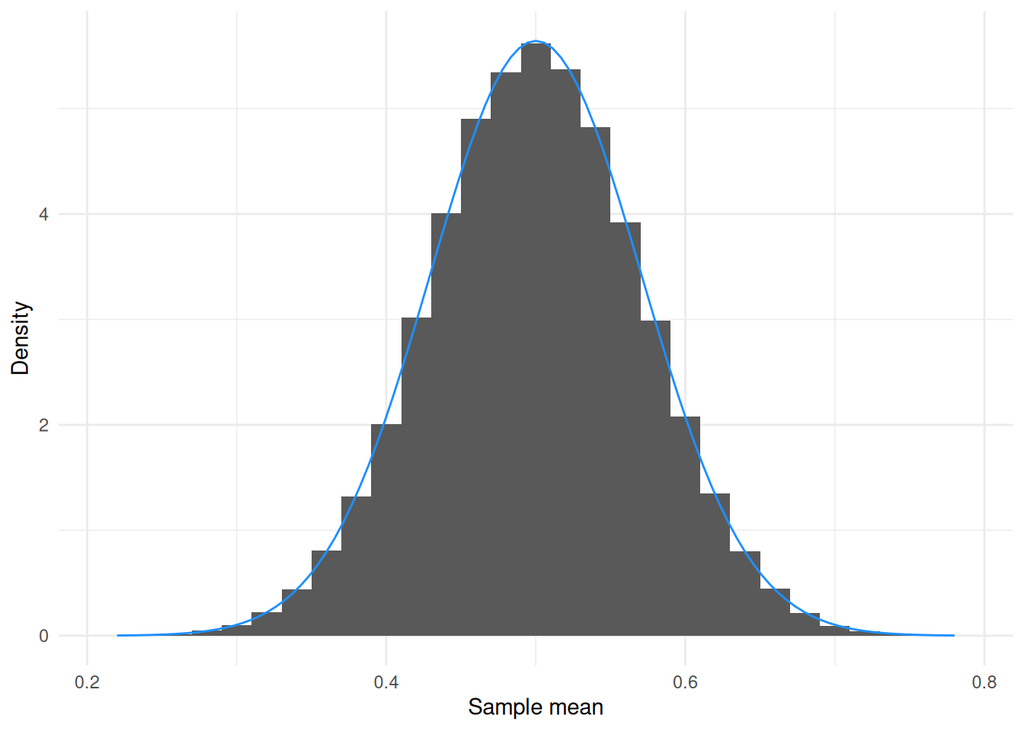

```r
# What's its distribution? It's not bernoulli! It's (roughly) normal (by the CLT)
tibble(xbar = sample_means) %>% ggplot(aes(x=xbar)) +
  geom_histogram(aes(y = after_stat(density)), binwidth=.02) +
  xlab("Sample mean") +
  ylab("Density") +
  stat_function(fun=dnorm, args=list(mean=.5, sd=sqrt(.25/50)),
                col="dodgerblue") + # Overlay a normal curve w/ asymptotic mean/variance
  theme_minimal()
```

## Illustration: The central limit theorem

Next, recall the Central Limit Theorem. If $X_{1}, X_{2}, ..., X_{n}$ are independent and identically distributed (i.i.d.) random variables with $E[X_i] < \infty$, $\mathbb{V}(X_{i}) = \sigma^2 < \infty$, $\sqrt{n} (\frac{1}{n} \sum_{i = 1}^{n} X_i - \mathbb{E}[X_{i}]) \xrightarrow[]{D} N(0, \sigma^2)$.

In the simulation below, we show how well the normal approximation holds for a given finite sample. We will use an i.i.d. Bernoulli random variable with $\mathbb{P}[X_{i} = 1] = 0.5$. Thus, $\mathbb{E}[X_{i}] = 0.5$ and $\sigma^2 = 0.25$.

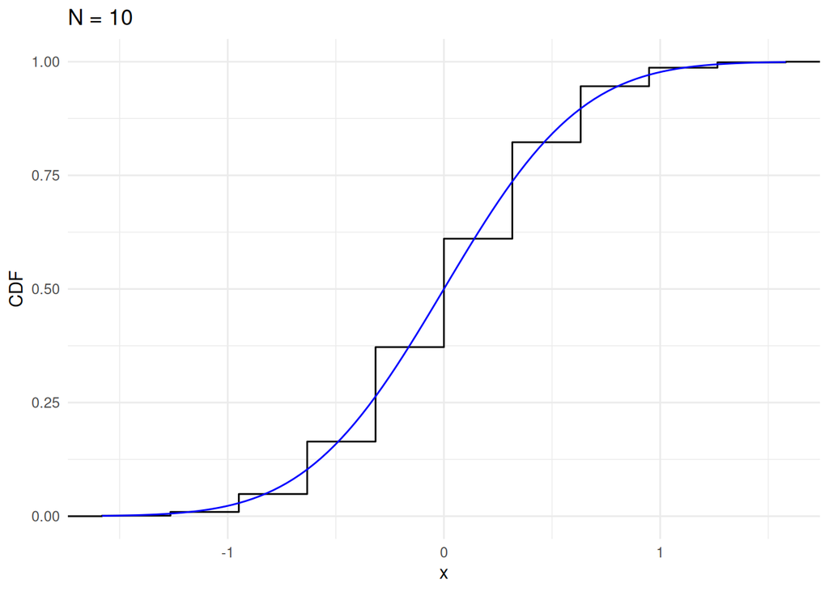

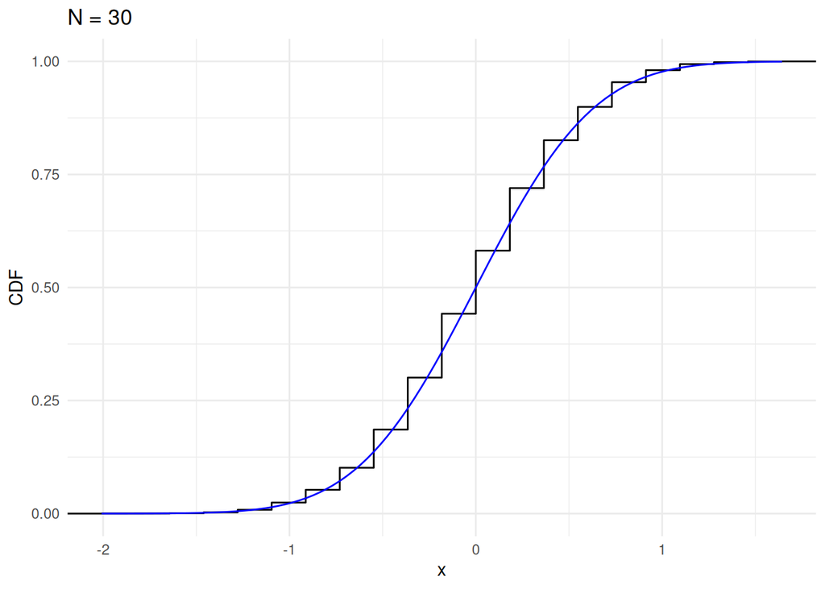

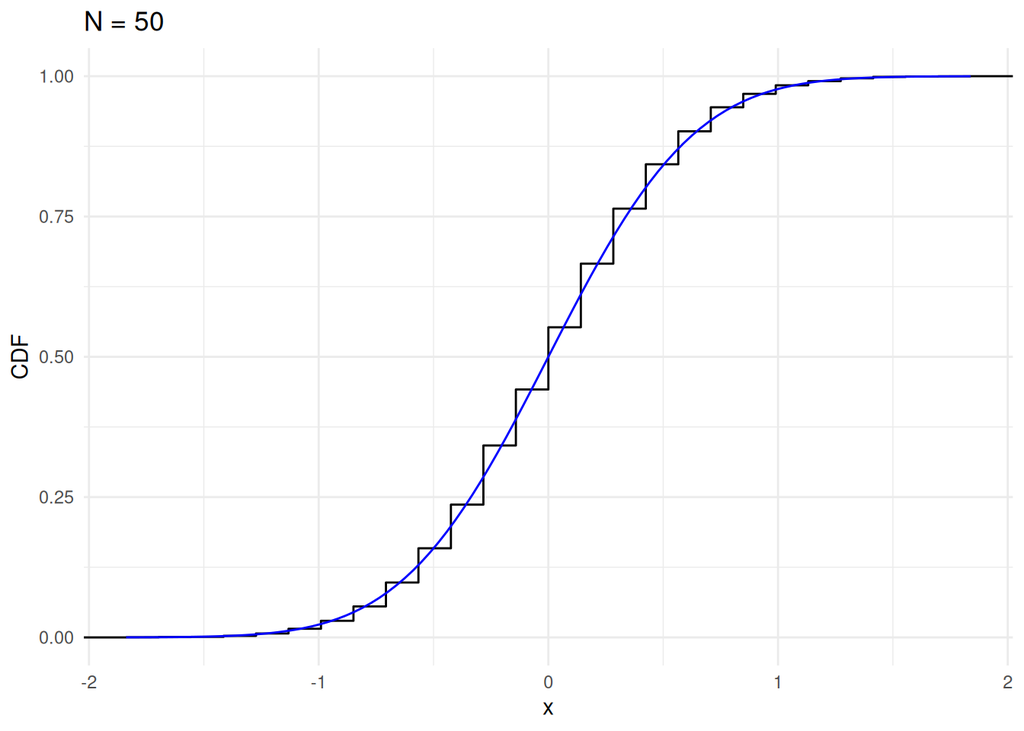

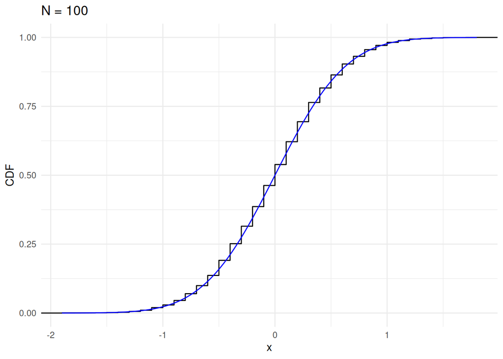

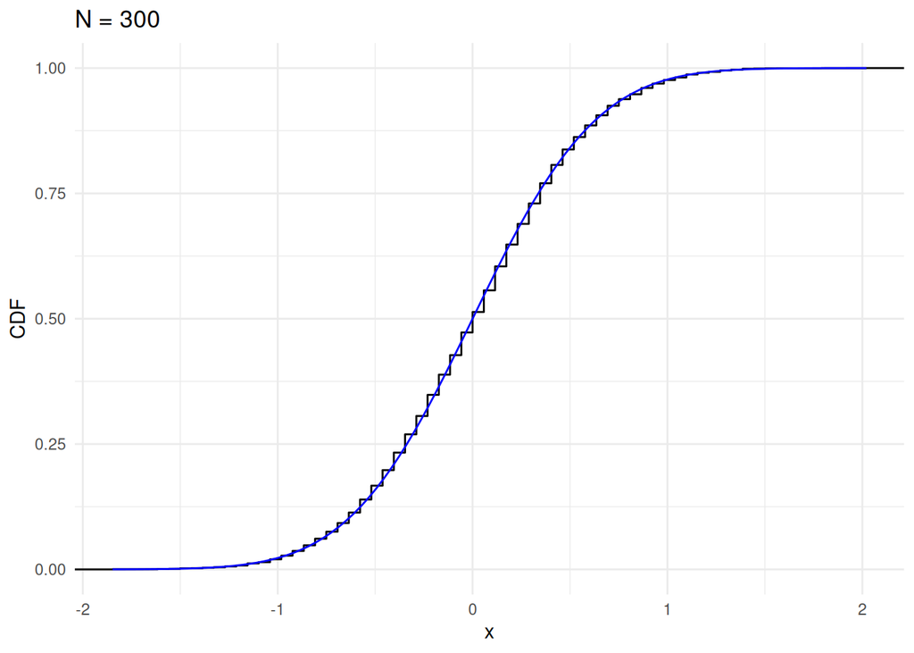

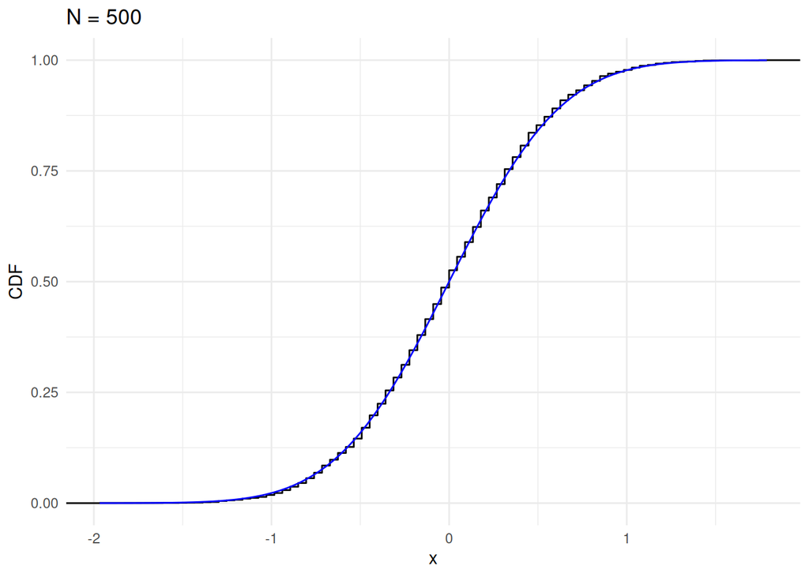

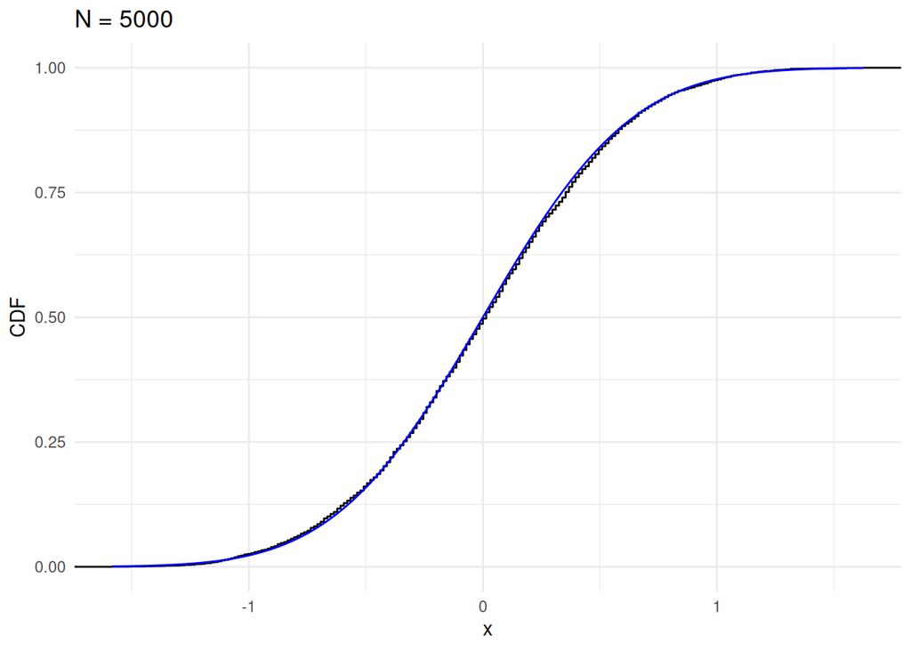

```r
# set seed to make results replicable
set.seed(53706)

# Loop over different sample sizes
samp_sizes <- c(10, 30, 50, 100, 300, 500, 5000)

# for each sample size, iterate 5000 times
niter <- 5000
# loop over different n, i.e., sample size: 10, 30, 50, 100, 300, 500, 5000
for(samp_size in samp_sizes){
  clt_seq <- rep(NA, niter) # create a vector to store the results

  # Run the monte carlo
  for(i in 1:niter){
    # compute the (rescaled) draws
    clt_seq[i] <- sqrt(samp_size) * (mean(rbinom(n = samp_size,
                                                 size = 1,
                                                 prob = .5)) - 0.5)
  }

  # save plot to compare the empirical CDF with normal CDF
  plot <- tibble(clt_sim = clt_seq) %>% ggplot(aes(x = clt_sim)) +
          stat_ecdf(geom = "step") +
          xlab("x") +
          ylab("CDF") +
          stat_function(fun = pnorm, args =  list(mean = 0, sd = 0.5),
                        col = "blue")+  theme_minimal() + ggtitle(label = paste0("N = ", samp_size))

  # plot figures
  print(plot)

}
```

## Illustration: Bias of the uncorrected sampling variance estimator

Recall our classic setup for estimating a population mean $\mu$ using $N$ i.i.d. samples $X_i$ with $E[X_i] = \mu$, $Var(X_i) = \sigma^2$ (no assumptions on the *distribution* of $X_i$, just its moments). Our estimator $\hat{\mu} = \bar{X} = \frac{1}{N}\sum_{i=1}^N X_i$ has some known properties. We know $E[\hat{\mu}] = \mu$ and that it is therefore *unbiased*. We know that its true sampling variance is $Var(\hat{\mu}) = \frac{\sigma^2}{N}$ and by extension the standard error is $\frac{\sigma}{\sqrt{N}}$.

However, if we want to construct confidence intervals and do inference, we need $Var(\hat{\mu})$, but we do not know $\sigma^2$. We therefore have to *estimate* using some estimator. One straightforward approach simply plugs in an estimate of $\sigma^2$, $\hat{\sigma^2}$ giving $\widehat{Var(\hat{\mu})} = \frac{\hat{\sigma^2}}{N}$. But how should we construct our estimator $\hat{\sigma^2}$? Well, the variance is defined as $E[(X - E[X])^2]$, the average of the squared deviations from the mean. We can use the sample analogue $\hat{\sigma^2}_{\text{uncorrected}} = \frac{1}{N}\sum_{i=1}^N (X_i - \bar{X})^2$. However, this estimator turns out to be *biased* although it is *consistent*. It turns out that using $N-1$ instead of $N$ addreses this bias $\hat{\sigma^2}_{\text{corrected}} = \frac{1}{N-1}\sum_{i=1}^N (X_i - \bar{X})^2$.

Let’s show this via simulation! Start by defining the data-generating process for a fixed value of $N = 30$, $\mu = 0$, $\sigma^2 = 4$, We’ll assume $X_i$ is normal, though this isn’t strictly necessary.

```r
# Set seed
set.seed(53706)

# Define the parameters of the DGP
N = 30
mu = 0
sigma = sqrt(4)

# Define a function to compute the unadjusted variance
var_unadj = function(x){
  return((1/length(x))*sum((x - mean(x))^2))
}

# Number of iterations
niter = 10000

# Run the simulation and get evaluations of the unadjusted variance
sim_results = 1:niter %>% map_dbl(function(x) var_unadj(rnorm(n=N, mean=mu, sd=sigma)))

# Calculate bias
mean(sim_results) - sigma^2
```

```
[1] -0.1108501
```

Now, we can show that this bias goes away when we use the $N-1$ correction (sometimes called “Bessel’s Correction”).

```r
# Set seed
set.seed(60615)

# Define the parameters of the DGP
N = 30
mu = 0
sigma = sqrt(4)

# Define a function to compute the unadjusted variance
# This function is equivalent to var() in R
var_adj = function(x){
  return((1/(length(x)-1))*sum((x - mean(x))^2))
}

# Number of iterations
niter = 10000

# Run the simulation and get evaluations of the unadjusted variance
sim_results_adj = 1:niter %>% map_dbl(function(x) var_adj(rnorm(n=N, mean=mu, sd=sigma)))

# Calculate bias
mean(sim_results_adj) - sigma^2
```

```
[1] -0.002327903
```

Let’s see how these two estimators compare across different values of N. There are lots of ways to do this. You could do a nested for loop – the outer loop varying N and the inner loop running all `niter` iterations. This will work but the code can look messy and confusing. We’ll stick with `map`, but nest it. `map` applies a function to each element of a list. We’ll pass the vectors in each list element to *another* call to map to do what we did above but for each sample size.

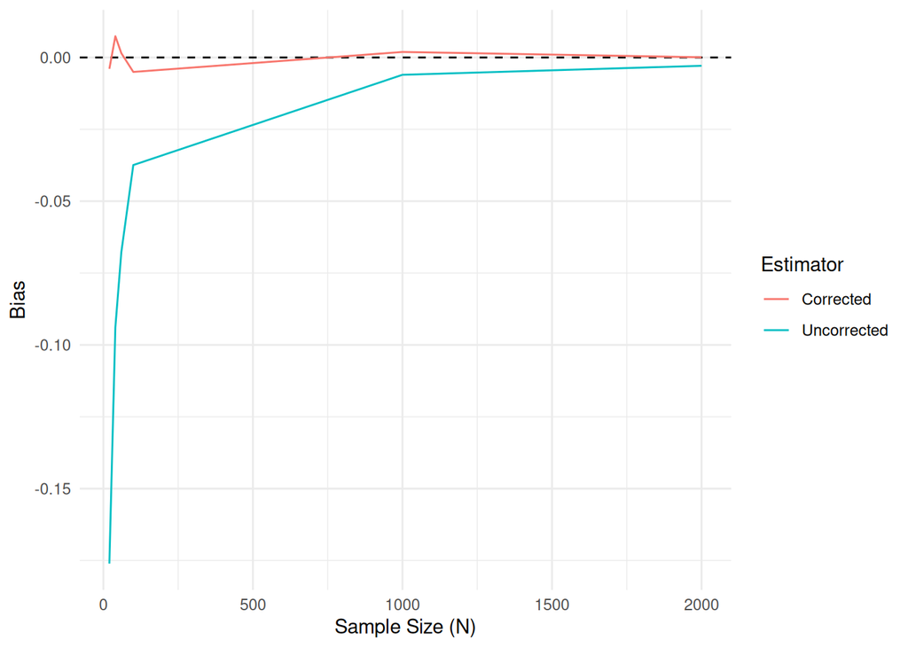

```r
# Set seed
set.seed(53706)

# Parameters
mu = 0
sigma = sqrt(4)

# Set range of Ns - this can be whatever you want, but more levels = more sims
N_vec = c(20, 40, 60, 100, 1000, 2000)
niter = 10000

# Make a list with N_vec elements each containing niter copies of the relevant sample size
iter_list <- N_vec %>% map(function(x) rep(x, niter))

# Use Map twice
# Then summarize each simulation run by taking the mean
sim_results_unadj <- iter_list %>%
    map(. %>% map_dbl(function(x) var_unadj(rnorm(n=x, mean=mu, sd=sigma)))) %>%
    map_dbl(mean)
    # Note that each vector contains the sample size,
    # so we're passing that sample size to the n argument in our in-line function (n=x).
sim_results_adj <- iter_list %>% map(. %>%
    map_dbl(function(x) var_adj(rnorm(n=x, mean=mu, sd=sigma)))) %>% map_dbl(mean)

# Put into a dataframe for plotting
plot_frame = data.frame(n = N_vec, Uncorrected = sim_results_unadj - sigma^2, Corrected = sim_results_adj-sigma^2)

# GGplot likes faceting by factors - let's go from wide to long here!
plot_frame <- plot_frame %>% pivot_longer(
    cols = c(Uncorrected, Corrected), names_to="Estimator", values_to = "Bias")

# Plot the results
plot_frame %>% ggplot(aes(x=n, y=Bias, colour=Estimator)) +
    geom_hline(yintercept = 0, lty=2) + geom_line() +
    xlab("Sample Size (N)") + ylab("Bias") +  theme_minimal()
```

# Acknowledgments

Special thanks to Zikai Li for developing an earlier version of this tutorial for PLSC 30600 at the University of Chicago.